# Data Mining

# Charles Book Club Case Solution

- Nhóm thực hiện:
- Nguyễn Ngọc Hòa: 18133014
- Lê Đình Khang: 18133021
- Trần Gia Nguyên: 18133036

# Giới thiệu

##### Câu lạc bộ sách Charles bán sách bằng cách tiếp thị trực tiếp, quảng cáo trên các phương tiện truyền thông, gửi thư. Hàng tháng họ gửi thư đến toàn bộ khách hàng có trong CSDL của họ.

##### ==> Có thể tăng lượng khách hàng, doanh thu nhưng rất tốn kém ==> Lợi nhuận giảm dần theo thời gian

#### Giải pháp:

##### Xây dựng mô hình dự đoán khả năng mua sách mới phát hành của khách hàng để giảm bớt chi phí tiếp thị

- Naive Bayes
- Logistic Regression
- KNN

##### Độ đo để đánh giá : ROC, AUC, TPR, FPR

# Tổng quan về dữ liệu

##### INPUT: Thông tin mua hàng của khách hàng và một số thông tin liên quan đến lịch sử thói quen mua sách của khách hàng

##### OUPUT: Biến Florence thể hiện khách hàng có mua sách The Art History of Florence hay không

```
## # A tibble: 4,000 x 20
##    Gender     M     R    Fr FirstPurch ChildBks YouthBks CookBks DoItYBks RefBks
##    <fct>  <dbl> <dbl> <dbl>      <dbl>    <dbl>    <dbl>   <dbl>    <dbl>  <dbl>
##  1 Female   297    14     2         22        0        1       1        0      0
##  2 Male     128     8     2         10        0        0       0        0      0
##  3 Female   138    22     7         56        2        1       2        0      1
##  4 Female   228     2     1          2        0        0       0        0      0
##  5 Female   257    10     1         10        0        0       0        0      0
##  6 Female   145     6     2         12        0        0       0        0      0
##  7 Female   190    16     1         16        0        0       0        0      0
##  8 Female   187    14     1         14        1        0       0        0      0
##  9 Female   252    10     1         10        0        0       0        0      0
## 10 Female   240     6     3         20        0        0       1        0      0
## # ... with 3,990 more rows, and 10 more variables: ArtBks <dbl>, GeogBks <dbl>,
## #   ItalCook <dbl>, ItalAtlas <dbl>, ItalArt <dbl>, Related Purchase <dbl>,
## #   Mcode <ord>, Rcode <ord>, Fcode <ord>, Florence <dbl>
```

# Giải thích các biến có trong tập dữ liệu

| Variables | Descriptions |
| --- | --- |
| Seq# | Số thứ tự của khách hàng trong tập dữ liệu này. |
| ID# | Số thứ tự của khách hàng trong cơ sở dữ liệu đầy đủ. |
| Gender | 0 = Nam, 1 = Nữ |
| M | Tổng số tiền chi cho việc mua sách |
| R | Số tháng kể từ lần cuối mua sách |
| F | Tổng số lần mua sách |
| FirstPurch | Số tháng kể từ lần mua sách đầu tiên |
| ChildBks | Số lần mua các quyển sách thuộc thể loại trẻ em |
| YouthBks | Số lần mua các quyển sách thuộc thể loại thanh thiếu niên |
| CookBks | Số lần mua các quyển sách thuộc thể loại nấu nướng |
| DoItYBks | Số lần mua các quyển sách thuộc thể loại self-help |
| RefBks | Số lần mua các quyển sách thuộc thể loại tham khảo(atlas, từ điển,…) |
| ArtBks | Số lần mua các quyển sách thuộc thể loại nghệ thuật |
| GeoBks | Số lần mua các quyển sách thuộc thể loại địa lý |
| ItalCook | Số lần mua quyển sách có tên ‘Secrets of Italian Cooking’ |
| ItalAtlas | Số lần mua quyển sách có tên ‘Historical Atlas of Italy’ |
| ItalArt | Số lần mua quyển sách có tên ‘Italian Art’ |
| MCode | Được tính dựa vào biến M ở trên($0–$25 (Mcode = 1), $26–$50 (Mcode = 2), $51–$100 (Mcode = 3), $101–$200 (Mcode = 4), $201 trở lên (Mcode = 5)) |
| RCode | Được tính dựa vào biến R ở trên(0–2 tháng (Rcode = 1), 3–6 tháng (Rcode = 2), 7–12 tháng (Rcode = 3), 13 trở lên (Rcode = 4)) |
| FCode | Được tính dựa vào biến F ở trên(1 cuốn (Fcode = l), 2 cuốn (Fcode = 2),3 cuốn trở lên (Fcode = 3)) |
| Related Purchase | Sô luong sách có liên quan da mua |
| Florence | = 1 neu The Art History of Florence đuoc mua; = 0 neu không |
| Yes_Florence | =1 nếu có mua sách The Art History of Florence ngược lại =0 |
| No_Florence | =1 nếu không mua sách The Art History of Florence ngược lại =0 |

# Tóm tắt các biến định lượng

|  | Count | Miss Pct. | Unique | Min. | 1st Qrt. | Median | Mean | 3rd Qrt. | Max | Std. |
| --- | --- | --- | --- | --- | --- | --- | --- | --- | --- | --- |
| M | 4000 | 0 | 446 | 15 | 129 | 208 | 208.091 | 283 | 479 | 100.949 |
| R | 4000 | 0 | 18 | 2 | 8 | 12 | 13.390 | 16 | 36 | 8.104 |
| Fr | 4000 | 0 | 12 | 1 | 1 | 2 | 3.833 | 6 | 12 | 3.458 |
| FirstPurch | 4000 | 0 | 48 | 2 | 12 | 20 | 26.507 | 36 | 99 | 18.351 |
| ChildBks | 4000 | 0 | 8 | 0 | 0 | 0 | 0.640 | 1 | 7 | 0.994 |
| YouthBks | 4000 | 0 | 6 | 0 | 0 | 0 | 0.305 | 0 | 5 | 0.612 |
| CookBks | 4000 | 0 | 8 | 0 | 0 | 0 | 0.731 | 1 | 7 | 1.089 |
| DoItYBks | 4000 | 0 | 6 | 0 | 0 | 0 | 0.351 | 1 | 5 | 0.688 |
| RefBks | 4000 | 0 | 5 | 0 | 0 | 0 | 0.256 | 0 | 4 | 0.558 |
| ArtBks | 4000 | 0 | 6 | 0 | 0 | 0 | 0.289 | 0 | 5 | 0.601 |
| GeogBks | 4000 | 0 | 7 | 0 | 0 | 0 | 0.388 | 1 | 6 | 0.751 |
| ItalCook | 4000 | 0 | 4 | 0 | 0 | 0 | 0.125 | 0 | 3 | 0.385 |
| ItalAtlas | 4000 | 0 | 3 | 0 | 0 | 0 | 0.038 | 0 | 2 | 0.215 |
| ItalArt | 4000 | 0 | 3 | 0 | 0 | 0 | 0.046 | 0 | 2 | 0.221 |
| Related Purchase | 4000 | 0 | 9 | 0 | 0 | 0 | 0.885 | 1 | 8 | 1.226 |
| Florence | 4000 | 0 | 2 | 0 | 0 | 0 | 0.084 | 0 | 1 | 0.278 |

# Tóm tắt các biến phân loại

|  | Count | Miss Pct. | Card. | Mode | Mode Freq. | Mode Pct. | 2nd Mode | 2nd Mode Freq. | 2nd Mode Pct. |
| --- | --- | --- | --- | --- | --- | --- | --- | --- | --- |
| Gender | 4000 | 0 | 2 | Female | 2818 | 70.4 | Male | 1182 | 29.5 |
| Mcode | 4000 | 0 | 5 | $201+ | 2092 | 52.3 | $101-200 | 1202 | 30.0 |
| Rcode | 4000 | 0 | 4 | 13+ months | 1826 | 45.6 | 7-12 months | 1322 | 33.1 |
| Fcode | 4000 | 0 | 3 | 3+ books | 1570 | 39.2 | 1 book | 1227 | 30.7 |

# Phân vùng dữ liệu

##### Ta sẽ chia dữ liệu thành tập train và tập test với tỉ lệ 7:3

##### Tập train

```
## # A tibble: 2,801 x 20
##    Gender     M     R    Fr FirstPurch ChildBks YouthBks CookBks DoItYBks RefBks
##    <fct>  <dbl> <dbl> <dbl>      <dbl>    <dbl>    <dbl>   <dbl>    <dbl>  <dbl>
##  1 Female   297    14     2         22        0        1       1        0      0
##  2 Male     128     8     2         10        0        0       0        0      0
##  3 Female   228     2     1          2        0        0       0        0      0
##  4 Female   257    10     1         10        0        0       0        0      0
##  5 Female   190    16     1         16        0        0       0        0      0
##  6 Female   187    14     1         14        1        0       0        0      0
##  7 Female   252    10     1         10        0        0       0        0      0
##  8 Female   240     6     3         20        0        0       1        0      0
##  9 Female   275     2     4         20        0        0       1        0      0
## 10 Male     320     2     3         18        0        0       0        0      0
## # ... with 2,791 more rows, and 10 more variables: ArtBks <dbl>, GeogBks <dbl>,
## #   ItalCook <dbl>, ItalAtlas <dbl>, ItalArt <dbl>, Related Purchase <dbl>,
## #   Mcode <ord>, Rcode <ord>, Fcode <ord>, Florence <fct>
```

# Phân vùng dữ liệu

##### Tập test

```
## # A tibble: 1,199 x 20
##    Gender     M     R    Fr FirstPurch ChildBks YouthBks CookBks DoItYBks RefBks
##    <fct>  <dbl> <dbl> <dbl>      <dbl>    <dbl>    <dbl>   <dbl>    <dbl>  <dbl>
##  1 Female   138    22     7         56        2        1       2        0      1
##  2 Female   145     6     2         12        0        0       0        0      0
##  3 Female   268     4     1          4        0        0       0        0      0
##  4 Male     135    14     1         14        1        0       0        0      0
##  5 Female   256    14     9         58        2        0       3        0      1
##  6 Male     260    34    11         74        0        2       3        5      0
##  7 Female   172    16     1         16        0        0       0        0      1
##  8 Male     317    10     3         28        0        0       0        0      0
##  9 Male      49    22     3         32        0        0       1        1      0
## 10 Female   355    16     5         28        1        0       2        0      1
## # ... with 1,189 more rows, and 10 more variables: ArtBks <dbl>, GeogBks <dbl>,
## #   ItalCook <dbl>, ItalAtlas <dbl>, ItalArt <dbl>, Related Purchase <dbl>,
## #   Mcode <ord>, Rcode <ord>, Fcode <ord>, Florence <fct>
```

# Tỉ lệ mua và không mua sách ở 2 tập train và test

Để tránh việc phân vùng dữ liệu một cách thiên vị, ta kiểm tra lại tỉ lệ mua sách trên train và test:

```
##
##         No        Yes
## 0.91538736 0.08461264
```

```
##
##         No        Yes
## 0.91576314 0.08423686
```

# Phân tích thăm dò tập train

##### Tóm tắt thống kê

|  | Count | Miss Pct. | Unique | Min. | 1st Qrt. | Median | Mean | 3rd Qrt. | Max | Std. |
| --- | --- | --- | --- | --- | --- | --- | --- | --- | --- | --- |
| M | 2801 | 0 | 432 | 15 | 128 | 209 | 207.758 | 281 | 477 | 101.687 |
| R | 2801 | 0 | 18 | 2 | 8 | 12 | 13.487 | 16 | 36 | 8.110 |
| Fr | 2801 | 0 | 12 | 1 | 1 | 2 | 3.802 | 6 | 12 | 3.464 |
| FirstPurch | 2801 | 0 | 48 | 2 | 12 | 20 | 26.380 | 36 | 99 | 18.380 |
| ChildBks | 2801 | 0 | 8 | 0 | 0 | 0 | 0.634 | 1 | 7 | 0.991 |
| YouthBks | 2801 | 0 | 6 | 0 | 0 | 0 | 0.305 | 0 | 5 | 0.612 |
| CookBks | 2801 | 0 | 8 | 0 | 0 | 0 | 0.727 | 1 | 7 | 1.086 |
| DoItYBks | 2801 | 0 | 6 | 0 | 0 | 0 | 0.342 | 0 | 5 | 0.682 |
| RefBks | 2801 | 0 | 5 | 0 | 0 | 0 | 0.260 | 0 | 4 | 0.564 |
| ArtBks | 2801 | 0 | 6 | 0 | 0 | 0 | 0.288 | 0 | 5 | 0.602 |
| GeogBks | 2801 | 0 | 7 | 0 | 0 | 0 | 0.400 | 1 | 6 | 0.772 |
| ItalCook | 2801 | 0 | 4 | 0 | 0 | 0 | 0.128 | 0 | 3 | 0.393 |
| ItalAtlas | 2801 | 0 | 3 | 0 | 0 | 0 | 0.036 | 0 | 2 | 0.211 |
| ItalArt | 2801 | 0 | 3 | 0 | 0 | 0 | 0.044 | 0 | 2 | 0.213 |
| Related Purchase | 2801 | 0 | 9 | 0 | 0 | 0 | 0.897 | 1 | 8 | 1.249 |

# Phân tích thăm dò tập train

|  | Count | Miss Pct. | Card. | Mode | Mode Freq. | Mode Pct. | 2nd Mode | 2nd Mode Freq. | 2nd Mode Pct. |
| --- | --- | --- | --- | --- | --- | --- | --- | --- | --- |
| Gender | 2801 | 0 | 2 | Female | 1971 | 70.4 | Male | 830 | 29.6 |
| Mcode | 2801 | 0 | 5 | $201+ | 1472 | 52.6 | $101-200 | 833 | 29.7 |
| Rcode | 2801 | 0 | 4 | 13+ months | 1301 | 46.4 | 7-12 months | 919 | 32.8 |
| Fcode | 2801 | 0 | 3 | 3+ books | 1072 | 38.3 | 2 books | 868 | 31.0 |
| Florence | 2801 | 0 | 2 | No | 2564 | 91.5 | Yes | 237 | 8.5 |

# Phân tích thăm dò tập train

- Trung bình của các yếu tố của người mua và không mua The Art History of Florence

|  | No | Yes |
| --- | --- | --- |
| M_mean | 206.9466 | 216.5316 |
| R_mean | 13.65367 | 11.67932 |
| Fr_mean | 3.708268 | 4.818565 |
| FirstPurch_mean | 26.1876 | 28.4557 |
| ChildBks_mean | 0.6267551 | 0.7130802 |
| YouthBks_mean | 0.2995320 | 0.3670886 |
| CookBks_mean | 0.725819 | 0.742616 |
| DoItYBks_mean | 0.3397036 | 0.3713080 |
| RefBks_mean | 0.2515601 | 0.3459916 |
| ArtBks_mean | 0.2683307 | 0.5063291 |
| GeogBks_mean | 0.3837754 | 0.5738397 |
| ItalCook_mean | 0.1267551 | 0.1392405 |
| ItalAtlas_mean | 0.03432137 | 0.05907173 |
| ItalArt_mean | 0.03978159 | 0.09282700 |
| Related Purchase_mean | 0.8529641 | 1.3713080 |

# Phân tích thăm dò tập train

##### Dùng kiểm định t-test để kiểm tra xem liệu có sự khác biệt về mặt thói quen mua hàng giữa người mua và người không mua sách mới hay không!

| Category | p_value |
| --- | --- |
| M | 0.1951 |
| R | 0.0001 |
| Fr | 0.0000 |
| FirstPurch | 0.0690 |
| ChildBks | 0.1661 |
| YouthBks | 0.1169 |
| CookBks | 0.8155 |
| DoItYBks | 0.5051 |
| RefBks | 0.0312 |
| ArtBks | 0.0000 |
| GeogBks | 0.0011 |
| ItalCook | 0.6400 |
| ItalAtlas | 0.1458 |
| ItalArt | 0.0092 |
| Related Purchase | 0.0000 |

# Phân tích thăm dò tập train

##### Trực quan hóa biến Recency (lần cuối cùng mua hàng)

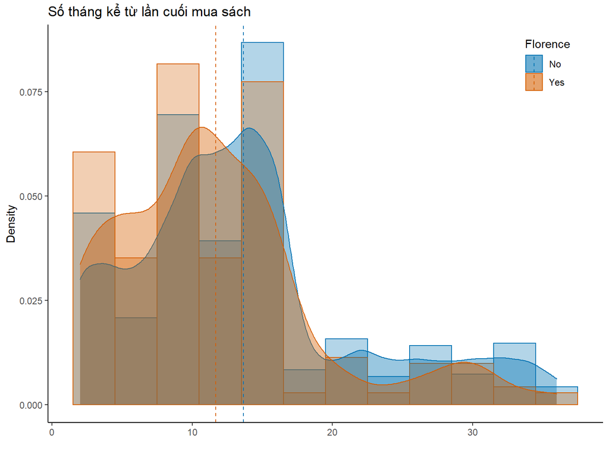

# Phân tích thăm dò tập train

##### Trực quan hóa biến Frequency(tần suất mua hàng)

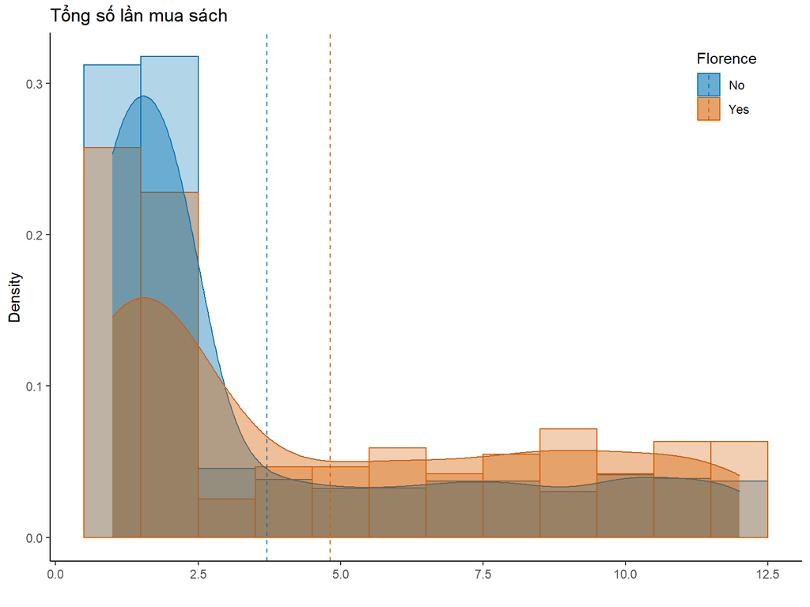

# Phân tích thăm dò tập train

##### Trực quan hóa biến Monetary (Chi tiêu cho việc mua sách)

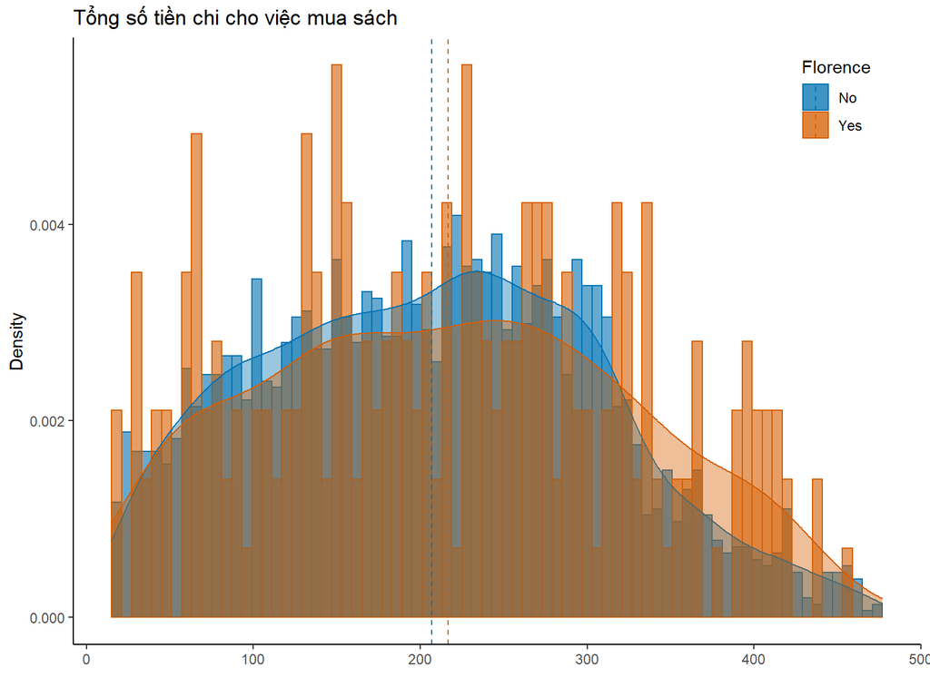

# Phân tích thăm dò tập train

##### Trực quan hóa biến First Purchase (lần đầu tiên mua sách)

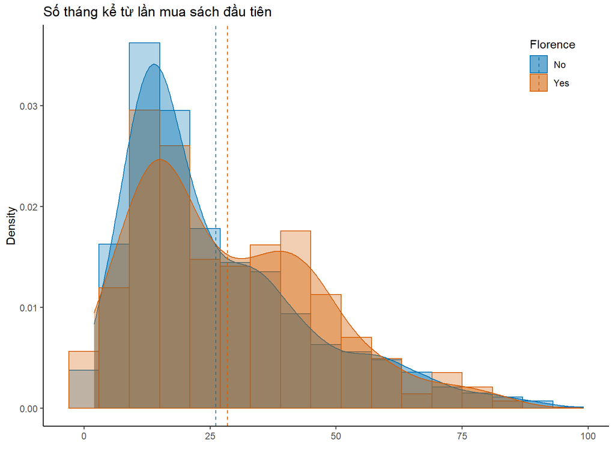

# Mức độ tương quan

Mức độ tương quan giữa các biến họ RFM

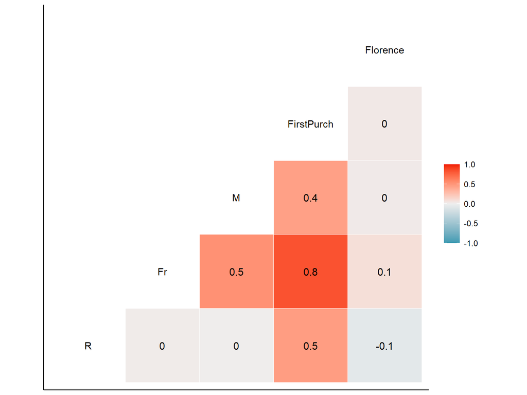

# Mức độ tương quan

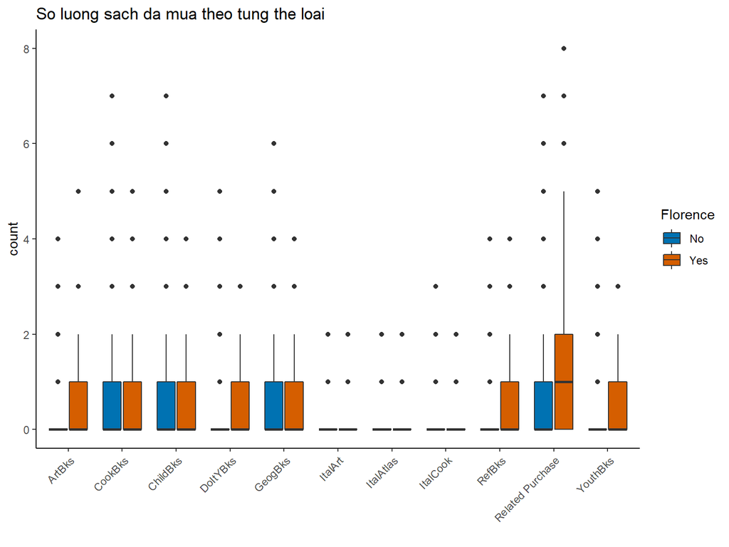

# Ma trận tương quan của tất cả các biến

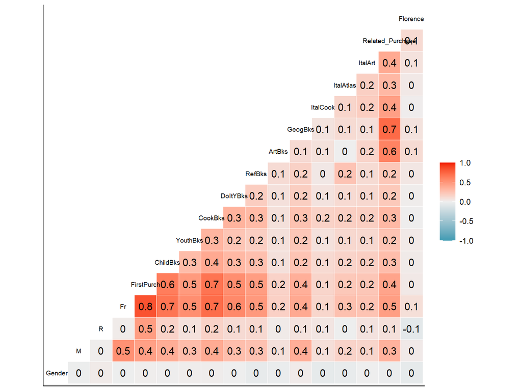

# Xây dựng mô hình

- Naive Bayes
- Logistic Regression
- KNN

# Mô hình KNN

##### Xây dựng mô hình KNN với các biến RFM_code, gender, FirstPurch và Relate.Purchase

```
## k-Nearest Neighbors
##
## 2801 samples
##    6 predictor
##    2 classes: 'No', 'Yes'
##
## Pre-processing: centered (12), scaled (12)
## Resampling: Cross-Validated (5 fold, repeated 1 times)
## Summary of sample sizes: 2240, 2241, 2242, 2241, 2240
## Resampling results across tuning parameters:
##
##   k   ROC        Sens       Spec
##    1  0.5057298  0.9434530  0.071985816
##    2  0.5032497  0.9629462  0.063386525
##    3  0.5002984  0.9820602  0.042109929
##    4  0.5240898  0.9875206  0.021010638
##    5  0.5176749  0.9949303  0.021099291
##    6  0.5254234  0.9968811  0.012765957
##    7  0.5336489  0.9980507  0.004255319
##    8  0.5358382  0.9984398  0.004255319
##    9  0.5384288  0.9996101  0.000000000
##   10  0.5332533  0.9996101  0.000000000
##   11  0.5283256  0.9996101  0.000000000
##   12  0.5353210  1.0000000  0.000000000
##   13  0.5384830  1.0000000  0.000000000
##   14  0.5416739  1.0000000  0.000000000
##   15  0.5404948  1.0000000  0.000000000
##
## ROC was used to select the optimal model using the largest value.
## The final value used for the model was k = 14.
```

# Mô hình KNN

##### Thêm 2 biến ArtBks và GeogBks vào mô hình. Chuyển đổi 2 biến về dạng phân loại (có mua và không mua)

```
## k-Nearest Neighbors
##
## 2801 samples
##    8 predictor
##    2 classes: 'No', 'Yes'
##
## Pre-processing: centered (14), scaled (14)
## Resampling: Cross-Validated (5 fold, repeated 1 times)
## Summary of sample sizes: 2242, 2240, 2241, 2241, 2240
## Resampling results across tuning parameters:
##
##   k   ROC        Sens       Spec
##    1  0.5066521  0.9411108  0.092819149
##    2  0.5093917  0.9512465  0.067464539
##    3  0.5212654  0.9781524  0.046453901
##    4  0.5221251  0.9832267  0.033776596
##    5  0.5414664  0.9925911  0.016843972
##    6  0.5448333  0.9910309  0.016932624
##    7  0.5474316  0.9957100  0.000000000
##    8  0.5592220  0.9953209  0.012677305
##    9  0.5569458  0.9964905  0.004166667
##   10  0.5551235  0.9980507  0.004166667
##   11  0.5635745  0.9984405  0.004166667
##   12  0.5558123  0.9992203  0.008421986
##   13  0.5681558  0.9996101  0.004255319
##   14  0.5733788  0.9996101  0.004255319
##   15  0.5758508  1.0000000  0.000000000
##
## ROC was used to select the optimal model using the largest value.
## The final value used for the model was k = 15.
```

# Mô hình KNN

##### Thử biến đổi biến First Purch thành biến nhị phân với số tháng lớn hơn bằng 24 thì nhận giá trị 1 và ngược lại

```
## k-Nearest Neighbors
##
## 2801 samples
##    8 predictor
##    2 classes: 'No', 'Yes'
##
## Pre-processing: centered (14), scaled (14)
## Resampling: Cross-Validated (5 fold, repeated 1 times)
## Summary of sample sizes: 2241, 2240, 2241, 2240, 2242
## Resampling results across tuning parameters:
##
##   k   ROC        Sens       Spec
##    1  0.4770933  0.9738715  0.058953901
##    2  0.4921024  0.9781585  0.046365248
##    3  0.5133316  0.9910278  0.025265957
##    4  0.5189566  0.9910278  0.021099291
##    5  0.5163420  0.9937561  0.008421986
##    6  0.5295998  0.9949287  0.008421986
##    7  0.5400013  0.9964889  0.000000000
##    8  0.5408740  0.9976585  0.000000000
##    9  0.5400487  0.9980484  0.000000000
##   10  0.5403118  0.9980492  0.004166667
##   11  0.5395900  0.9976593  0.000000000
##   12  0.5424758  0.9996094  0.000000000
##   13  0.5445710  1.0000000  0.000000000
##   14  0.5508758  1.0000000  0.000000000
##   15  0.5513395  1.0000000  0.000000000
##
## ROC was used to select the optimal model using the largest value.
## The final value used for the model was k = 15.
```

# Mô hình Naive Bayes

Sử dụng các biến RFM Code và biến giới tính

```
## Naive Bayes
##
## 2801 samples
##    4 predictor
##    2 classes: 'No', 'Yes'
##
## No pre-processing
## Resampling: Cross-Validated (5 fold, repeated 1 times)
## Summary of sample sizes: 2240, 2242, 2241, 2241, 2240
## Resampling results across tuning parameters:
##
##   fL  usekernel  adjust  ROC        Sens  Spec
##   0   FALSE      0.0     0.5766818    1     0
##   0   FALSE      0.5     0.5766818    1     0
##   0   FALSE      1.0     0.5766818    1     0
##   0    TRUE      0.0           NaN  NaN   NaN
##   0    TRUE      0.5     0.5716707    1     0
##   0    TRUE      1.0     0.5730980    1     0
##   1   FALSE      0.0     0.5766818    1     0
##   1   FALSE      0.5     0.5766818    1     0
##   1   FALSE      1.0     0.5766818    1     0
##   1    TRUE      0.0           NaN  NaN   NaN
##   1    TRUE      0.5     0.5716707    1     0
##   1    TRUE      1.0     0.5730980    1     0
##   5   FALSE      0.0     0.5766818    1     0
##   5   FALSE      0.5     0.5766818    1     0
##   5   FALSE      1.0     0.5766818    1     0
##   5    TRUE      0.0           NaN  NaN   NaN
##   5    TRUE      0.5     0.5716707    1     0
##   5    TRUE      1.0     0.5730980    1     0
##
## ROC was used to select the optimal model using the largest value.
## The final values used for the model were fL = 0, usekernel = FALSE and adjust
##  = 0.
```

# Mô hình Naive Bayes

Thêm 2 yếu tố liên quan đến việc khách hàng có mua sách thuộc thể loại Nghệ thuật và địa lý hay không

```
## Naive Bayes
##
## 2801 samples
##    6 predictor
##    2 classes: 'No', 'Yes'
##
## No pre-processing
## Resampling: Cross-Validated (5 fold, repeated 1 times)
## Summary of sample sizes: 2241, 2241, 2241, 2241, 2240
## Resampling results across tuning parameters:
##
##   fL  usekernel  adjust  ROC        Sens       Spec
##   0   FALSE      0.0     0.6102338  0.9988304  0.008510638
##   0   FALSE      0.5     0.6102338  0.9988304  0.008510638
##   0   FALSE      1.0     0.6102338  0.9988304  0.008510638
##   0    TRUE      0.0           NaN        NaN          NaN
##   0    TRUE      0.5     0.6038179  1.0000000  0.000000000
##   0    TRUE      1.0     0.6054262  1.0000000  0.000000000
##   1   FALSE      0.0     0.6102338  0.9988304  0.008510638
##   1   FALSE      0.5     0.6102338  0.9988304  0.008510638
##   1   FALSE      1.0     0.6102338  0.9988304  0.008510638
##   1    TRUE      0.0           NaN        NaN          NaN
##   1    TRUE      0.5     0.6038179  1.0000000  0.000000000
##   1    TRUE      1.0     0.6054262  1.0000000  0.000000000
##   5   FALSE      0.0     0.6102338  0.9988304  0.008510638
##   5   FALSE      0.5     0.6102338  0.9988304  0.008510638
##   5   FALSE      1.0     0.6102338  0.9988304  0.008510638
##   5    TRUE      0.0           NaN        NaN          NaN
##   5    TRUE      0.5     0.6038179  1.0000000  0.000000000
##   5    TRUE      1.0     0.6054262  1.0000000  0.000000000
##
## ROC was used to select the optimal model using the largest value.
## The final values used for the model were fL = 0, usekernel = FALSE and adjust
##  = 0.
```

# Mô hình Naive Bayes

Thêm yếu tố liên quan đến khách hàng có mua sách trong vòng 24 tháng trở lại đây hay không

```
## Naive Bayes
##
## 2801 samples
##    7 predictor
##    2 classes: 'No', 'Yes'
##
## No pre-processing
## Resampling: Cross-Validated (5 fold, repeated 1 times)
## Summary of sample sizes: 2240, 2241, 2241, 2241, 2241
## Resampling results across tuning parameters:
##
##   fL  usekernel  adjust  ROC        Sens       Spec
##   0   FALSE      0.0     0.6104670  0.9964897  0.01693262
##   0   FALSE      0.5     0.6104670  0.9964897  0.01693262
##   0   FALSE      1.0     0.6104670  0.9964897  0.01693262
##   0    TRUE      0.0           NaN        NaN         NaN
##   0    TRUE      0.5     0.6059460  1.0000000  0.00000000
##   0    TRUE      1.0     0.6083816  1.0000000  0.00000000
##   1   FALSE      0.0     0.6104670  0.9964897  0.01693262
##   1   FALSE      0.5     0.6104670  0.9964897  0.01693262
##   1   FALSE      1.0     0.6104670  0.9964897  0.01693262
##   1    TRUE      0.0           NaN        NaN         NaN
##   1    TRUE      0.5     0.6059460  1.0000000  0.00000000
##   1    TRUE      1.0     0.6083816  1.0000000  0.00000000
##   5   FALSE      0.0     0.6104670  0.9964897  0.01693262
##   5   FALSE      0.5     0.6104670  0.9964897  0.01693262
##   5   FALSE      1.0     0.6104670  0.9964897  0.01693262
##   5    TRUE      0.0           NaN        NaN         NaN
##   5    TRUE      0.5     0.6059460  1.0000000  0.00000000
##   5    TRUE      1.0     0.6083816  1.0000000  0.00000000
##
## ROC was used to select the optimal model using the largest value.
## The final values used for the model were fL = 0, usekernel = FALSE and adjust
##  = 0.
```

# Mô hình Logistic Regression

sử dụng tất cả các biến ngoại trừ các biến RFM_Code và số lần mua gần đây vì chúng có mức độ tương quan cao với số lượng mua ở một số thể loại cụ thê

```
##
## Call:
## NULL
##
## Deviance Residuals:
##     Min       1Q   Median       3Q      Max
## -1.1669  -0.4359  -0.3642  -0.3033   2.7167
##
## Coefficients:
##                Estimate Std. Error z value Pr(>|z|)
## (Intercept)  -2.2854458  0.2349778  -9.726  < 2e-16 ***
## GenderFemale -0.3770192  0.1454529  -2.592 0.009541 **
## M            -0.0013025  0.0008243  -1.580 0.114080
## R            -0.0110373  0.0139511  -0.791 0.428862
## Fr            0.2765930  0.0610835   4.528 5.95e-06 ***
## FirstPurch   -0.0068449  0.0099612  -0.687 0.491980
## ChildBks     -0.2478495  0.1005610  -2.465 0.013714 *
## YouthBks     -0.2377516  0.1349796  -1.761 0.078173 .
## CookBks      -0.3590488  0.0977573  -3.673 0.000240 ***
## DoItYBks     -0.3059922  0.1285949  -2.380 0.017336 *
## RefBks       -0.0828560  0.1348442  -0.614 0.538913
## ArtBks        0.3659326  0.0959086   3.815 0.000136 ***
## GeogBks       0.1543235  0.0892652   1.729 0.083841 .
## ItalCook     -0.0710573  0.1808302  -0.393 0.694356
## ItalAtlas    -0.0221271  0.2998535  -0.074 0.941175
## ItalArt       0.5567232  0.2673323   2.083 0.037296 *
## ---
## Signif. codes:  0 '***' 0.001 '**' 0.01 '*' 0.05 '.' 0.1 ' ' 1
##
## (Dispersion parameter for binomial family taken to be 1)
##
##     Null deviance: 1624.0  on 2800  degrees of freedom
## Residual deviance: 1529.9  on 2785  degrees of freedom
## AIC: 1561.9
##
## Number of Fisher Scoring iterations: 5
```

# Mô hình Logistic Regression

Ngoài ra, chúng ta có thể thử xem các biến thể khác của logistic regression bằng cách sử dụng stepwise selection

```
##   parameter       ROC      Sens       Spec      ROCSD       SensSD     SpecSD
## 1      none 0.6195457 0.9996094 0.01258865 0.04624536 0.0008734641 0.01149324
```

```
##   parameter       ROC Sens        Spec      ROCSD SensSD     SpecSD
## 1      none 0.6366561    1 0.008421986 0.06943167      0 0.01153334
```

```
##   parameter       ROC Sens       Spec      ROCSD SensSD     SpecSD
## 1      none 0.6367675    1 0.01693262 0.04702144      0 0.01777587
```

# Mô hình Logistic Regression

```
##
## Call:  NULL
##
## Coefficients:
##  (Intercept)  GenderFemale             M             R            Fr
##    -2.285446     -0.377019     -0.001303     -0.011037      0.276593
##   FirstPurch      ChildBks      YouthBks       CookBks      DoItYBks
##    -0.006845     -0.247850     -0.237752     -0.359049     -0.305992
##       RefBks        ArtBks       GeogBks      ItalCook     ItalAtlas
##    -0.082856      0.365933      0.154324     -0.071057     -0.022127
##      ItalArt
##     0.556723
##
## Degrees of Freedom: 2800 Total (i.e. Null);  2785 Residual
## Null Deviance:       1624
## Residual Deviance: 1530  AIC: 1562
```

```
##
## Call:  NULL
##
## Coefficients:
##  (Intercept)  GenderFemale             M             R            Fr
##    -2.246575     -0.366576     -0.001307     -0.019362      0.237019
##     ChildBks      YouthBks       CookBks      DoItYBks        ArtBks
##    -0.241223     -0.225346     -0.359822     -0.299910      0.359855
##      GeogBks       ItalArt
##     0.153950      0.534669
##
## Degrees of Freedom: 2800 Total (i.e. Null);  2789 Residual
## Null Deviance:       1624
## Residual Deviance: 1531  AIC: 1555
```

```
##
## Call:  NULL
##
## Coefficients:
##  (Intercept)  GenderFemale             M             R            Fr
##    -2.246575     -0.366576     -0.001307     -0.019362      0.237019
##     ChildBks      YouthBks       CookBks      DoItYBks        ArtBks
##    -0.241223     -0.225346     -0.359822     -0.299910      0.359855
##      GeogBks       ItalArt
##     0.153950      0.534669
##
## Degrees of Freedom: 2800 Total (i.e. Null);  2789 Residual
## Null Deviance:       1624
## Residual Deviance: 1531  AIC: 1555
```

# Lựa chọn mô hình

#### Dựa vào kết quả phân tích ta sẽ lựa chọn

- Mô hình Naive Bayes với công thức như sau : Florence ~ Gender + Rcode + Fcode + Mcode + FirstPurch_2 + Art_1 + Geo_1
- Mô hình Logistic Regression với công thức như sau: Florence ~ Gender + M + R + Fr + ChildBks + CookBks + DoItYBks + ArtBks + GeogBks + YouthBks + ItalArt và sử dụng biến thể forward & backward stepwise
- Mô hình Knn với công thức như sau: Florence ~ Gender + Rcode + Fcode + Mcode + FirstPurch + Related Purchase + Art_1 + Geo_1

# Kiểm tra hiệu suất mô hình trên tập test

##### Đánh giá mô hình Naive Bayes bằng cách vẽ đồ thị TPR, FPR và ROC Score trên tập train và test

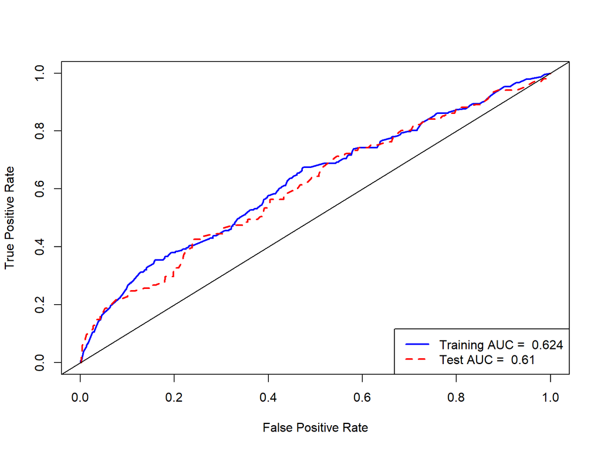

# Kiểm tra hiệu suất mô hình trên tập Test

##### Đánh giá mô hình KNN bằng cách vẽ đồ thị TPR, FPR và ROC Score trên tập train và test

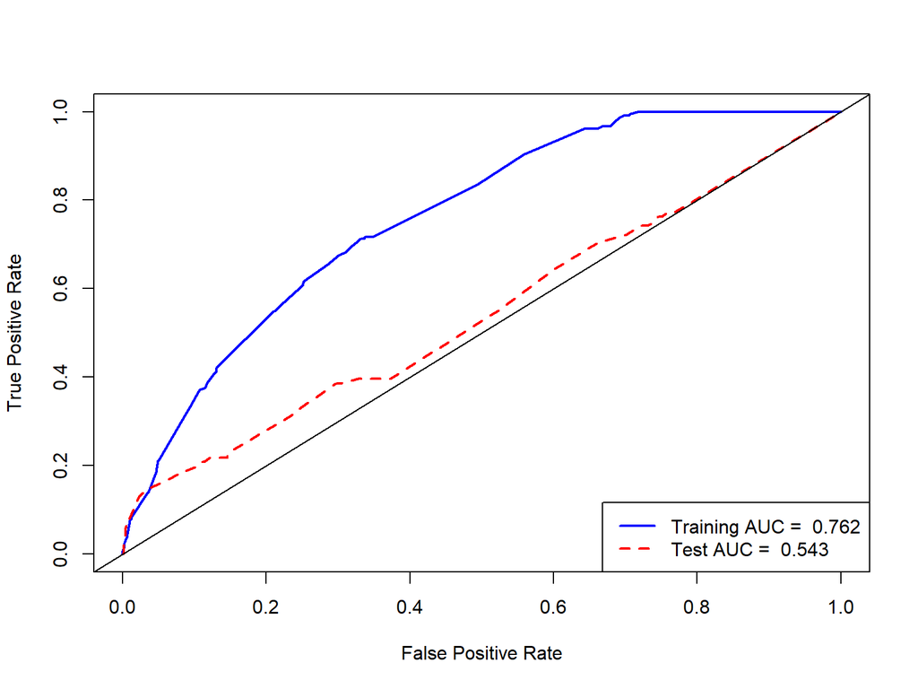

# Kiểm tra hiệu suất mô hình trên tập Test

##### Đánh giá mô hình Logistic Regression bằng cách vẽ đồ thị TPR, FPR và ROC Score trên tập train và test

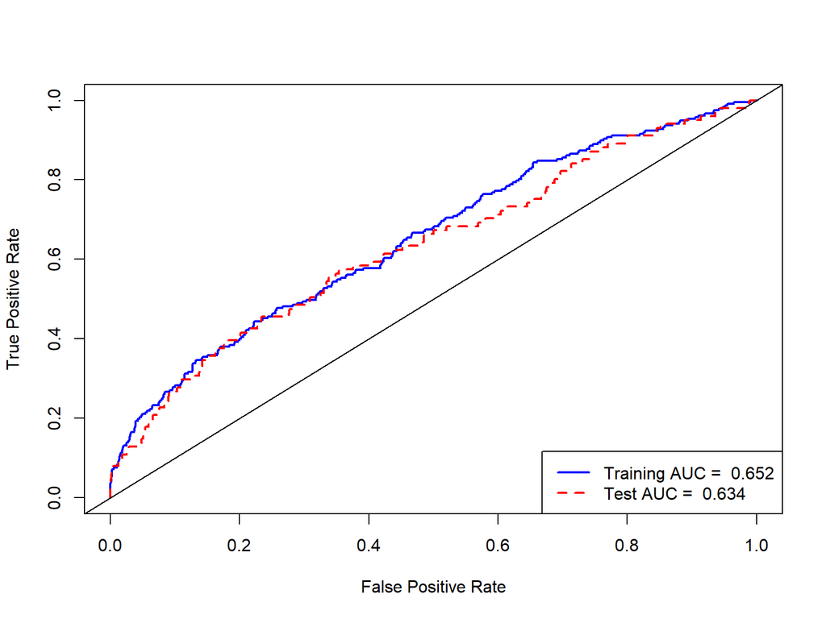

# Kết quả đạt được

- Sau khi xem xét hiệu suất của các mô hình trên tập test , chúng ta thấy mô hình hồi quy logistic hoạt động tốt hơn 2 mô hình còn lại và cung cấp cho chúng ta cơ hội giảm ngân sách marketing trực tiếp bằng cách nhắm mục tiêu các thành viên được dự đoán là có nhiều khả năng mua bản phát hành sách mới nhất.
- Về các yếu tố dự đoán, chúng ta thấy rằng nam giới có nhiều khả năng mua hàng hơn nữ giới, việc mua sách thuộc các thể loại như Nghệ thuật và Địa lý làm tăng xác suất mua sách và mua sách thể loại Cooking và DIY có tác động tiêu cực.
- Nên sử dụng kết hợp 2 mô hình hồi quy logisitic và mô hình Naive Bayes để dự đoán xu hướng mua hàng của cơ sở dữ liệu khách hàng và lưu trữ các dự đoán riêng lẻ và kết hợp của họ.

# Hạn chế và hướng phát triển

Hướng phát triển

- Mô hình của chúng ta có thể được cải thiện bằng cách tính vào tổng số tiền mua hàng mà người mua đã thực hiện khi phản hồi chiến dịch. Mặc dù nó sẽ không cải thiện dự đoán của một khách hàng, nhưng nó sẽ giúp cô lập khách hàng hơn nữa để tập trung các nỗ lực tiếp thị bằng cách sử dụng xác suất mua hàng cùng với giá trị mua hàng được dự đoán để tính lợi nhuận kỳ vọng từ mỗi khách hàng. Sau đó, mẫu của chúng ta có thể được xếp hạng dựa trên lợi nhuận dự kiến.
- Ngoài ra, các biến số hành vi khác có thể hữu ích, chẳng hạn như thời gian trung bình giữa những người mua hàng của thành viên (nhịp độ mua hàng chung của khách hàng là gì?), Chi tiêu trong 90 ngày qua (hoặc giá trị theo chu kỳ khác) và mua hàng trong 90 ngày qua ngày (hoặc giá trị theo chu kỳ khác).

# Hạn chế và hướng phát triển

Hạn chế

- KNN gần như gặp hiện tượng overfitting, để khắc phục có thể chia tập dữ liệu validation từ tập dữ liệu gốc.
- Cách lựa chọn các tham số cũng như thuật toán còn phụ thuộc nhiều vào yếu tố chủ quan, độ chính xác không cao.
- Thời gian và kiến thức hạn hẹp, không tránh khỏi những sai sót trong quá trình trình bày ý tưởng cũng như hiện thực hóa ý tưởng đó.